# Homework3

Merve Unal - IE582 - Fall 2018 - 2016702108

**1.INTRODUCTION**

There are 2 seperate tasks given and each task includes some sub-parts. In the first task includes 3 seperate subtasks. - In a part of first task, i observed one instance from each classes considering X,Y,Z axis and total form of XYZ axis. In the first class of a part of 1. task, I plotted data belonging each axis both without cumulative sum and with cumulative sum. But for the other classes, i observed XYZ plot of data without cumulative sum and cumulative sum data of plot belonging each axis and total form of xyz axis. Additionally, for this subtask’s codes can be seen in the code section. I added only first class’ codes. The only thing i changed to find other classes’ is to change the numbers(from 1 to 8)

- In b part of first task,first thing that i did is to filter each test classes’ X,Y and Z axis and after cumulative sum take the last column which is the point that the instance is situated. Then i combined X,Y and Z axis for each class. After that, i created a basic “for loop”" and combined train and test data for each class’ XYZ axis. Then, I found euclidean and manhattan distances.In order not to make my computer slower, i only demonstrated the first test class’ euclidean and manhattan distances. I repeated it for 8 times since the number of class is 8. But you can find only fist class’ codes in the code section. Since actually what i did is the same nearly. The only difference is to change class number(from 1 to 8). Then, i filtered each training classes’ X,Y and Z axis and after cumulative sum take the last column which is the point that the instance is situated. Then i combined X,Y and Z axis for each class. I created knn algorithm with 10 fold cross validation to determine the best value of k.
- In c part of first task, I predicted test data that i had created by using “rbind” function and prepared confusion matrix and gave some information and comments.

In the second task includes 4 seperate subtasks.

- In the a part of second task, I trained a logistic regression model on the training data using fused lasso penalties.I used “predict” function to predict the test data and tried to create confusion matrix.
- In the b part of second task, according to the regression coefficients that i found, I plotted to see some interesting information and tried to interpret.
- In the c part of second task,i took difference between time series by using “diff” function. Then, i repeated the a part.
- In the d part of second task, according to the regression coefficients that i found in c part, I plotted to see some interesting information and tried to interpret.

**2.FIGURES**

**TASK 1**

**Part a**

**For the 1. Class**

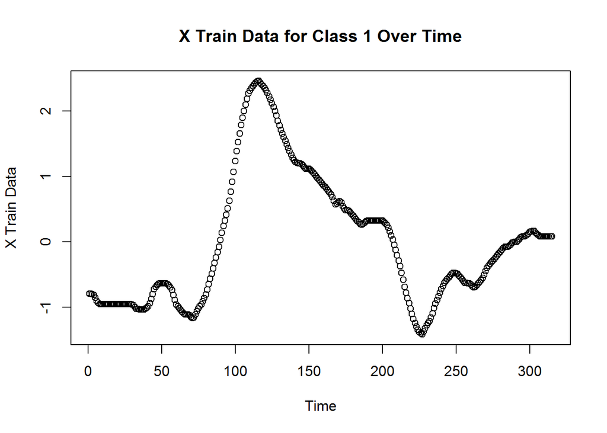

Figure 1: X train data for class 1 over time

As can be seen from the first graph, x axis of the train data without cumulative sum can be viewed.(For the first class)

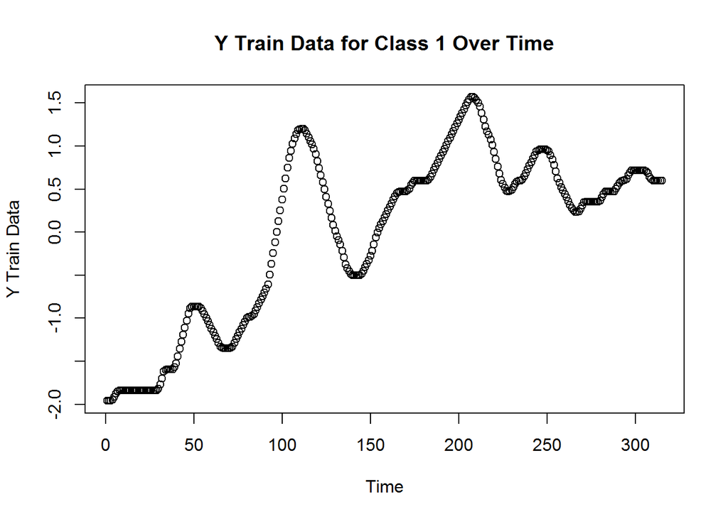

Figure 2: Y train data for class 1 over time

As can be seen from the first graph, Y axis of the train data without cumulative sum can be viewed.(For the first class)

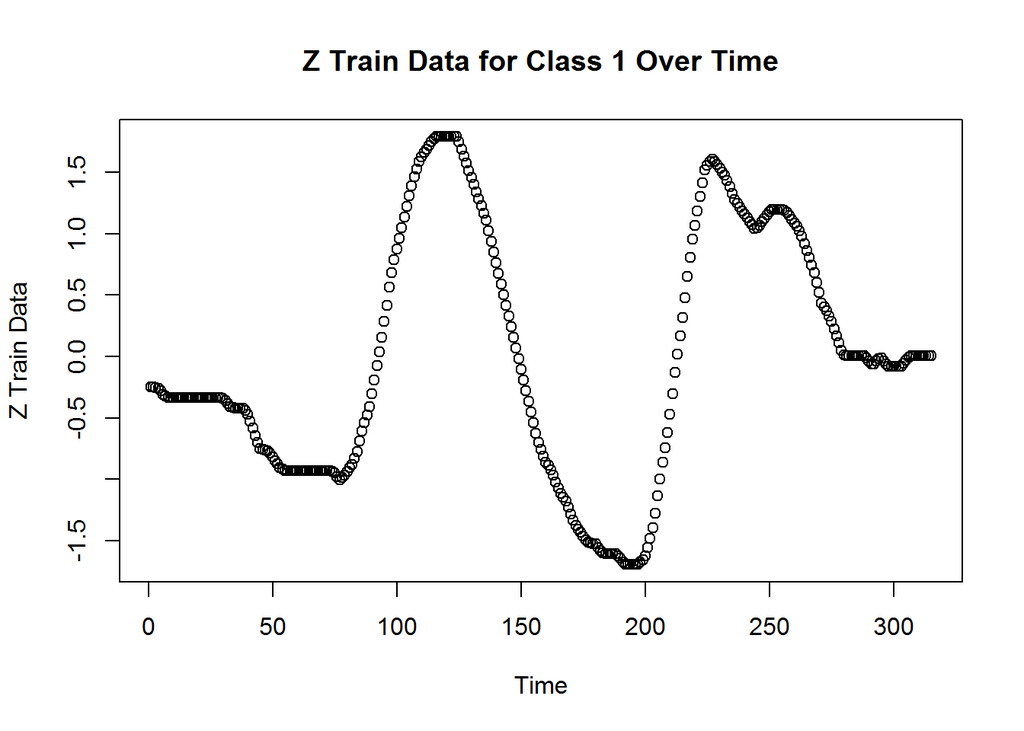

Figure 3: Z train data for class 1 over time

As can be seen from the first graph, Z axis of the train data without cumulative sum can be viewed.(For the first class)

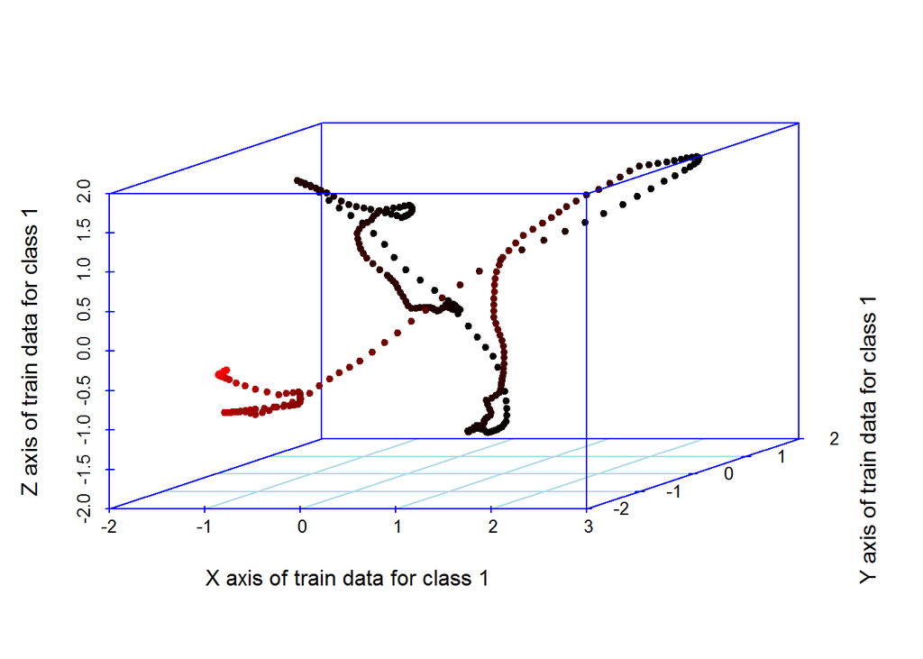

Figure 4: XYZ axis for class 1 without cumulative sum

If I want to see the combined version of x,y and z axis, this kind of plot can be observed.In this case, vectors are not cumulative.

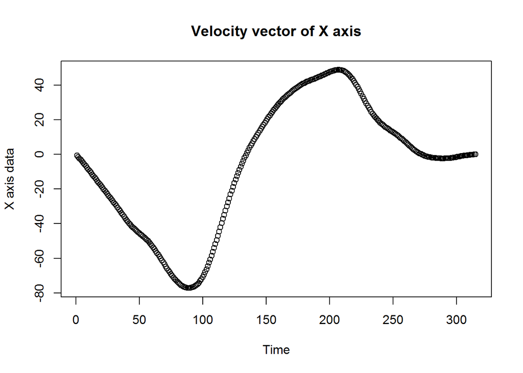

Figure 5: X axis for Class 1 with cumulative sum(Velocity vector of X axis)

This shows the graph of x axis belonging training data. In this case, cumulative sum is considered.

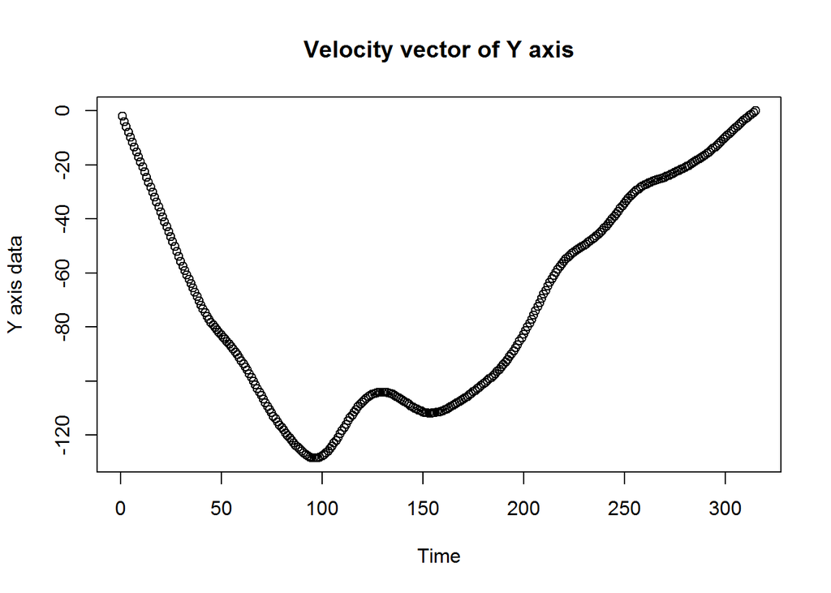

Figure 6: Y axis for Class 1 with cumulative sum(Velocity vector of Y axis)

This shows the graph of y axis belonging training data. In this case, cumulative sum is considered.

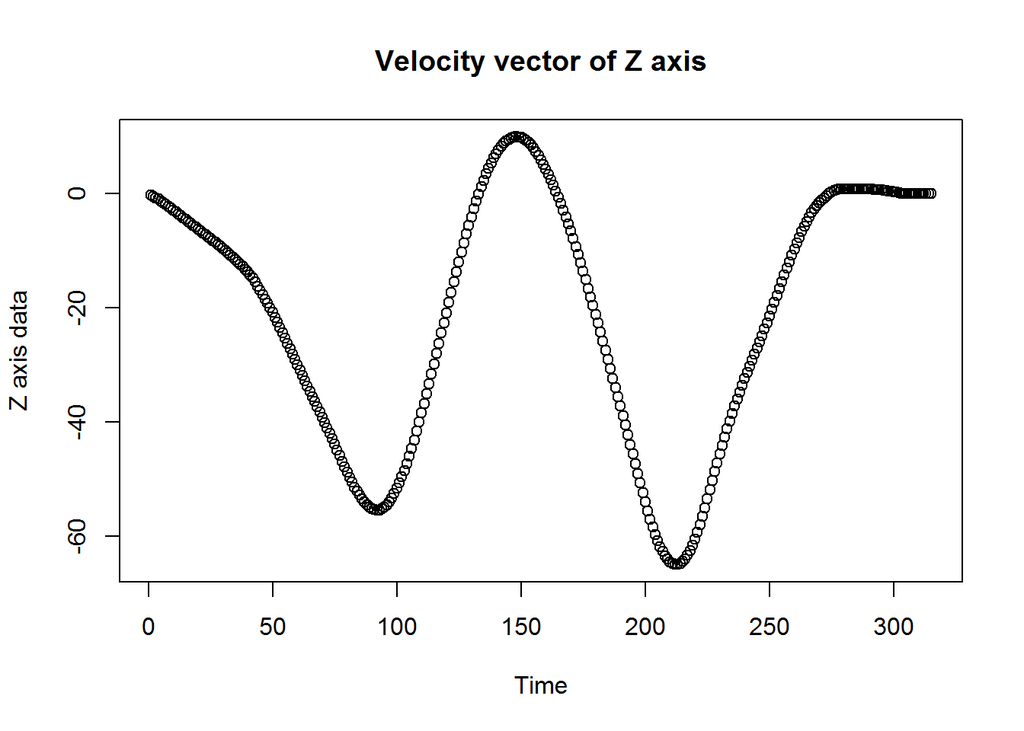

Figure 7: Z axis for Class 1 with cumulative sum(Velocity vector of Z axis)

This shows the graph of z axis belonging training data. In this case, cumulative sum is considered.

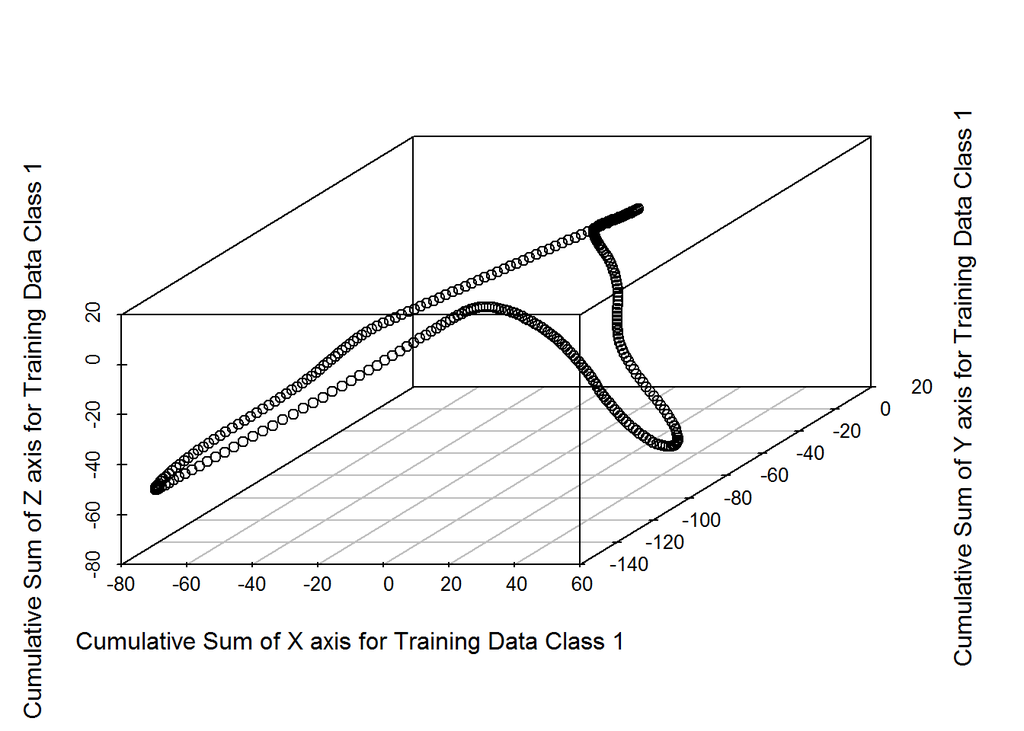

Figure 8: XYZ axis for Class 1 with cumulative sum(Velocity vector of XYZ axis)

This shows the graph of xyz axis belonging training data. In this case, cumulative sum is considered. This is the visualization of one instance of Class 1.

**For the 2. Class**

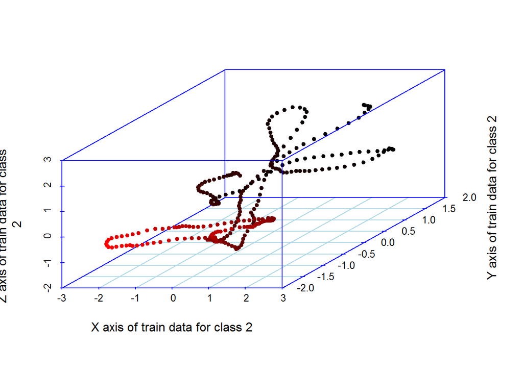

Figure 9: XYZ axis for class 2 without cumulative sum

If I want to see the combined version of x,y and z axis, this kind of plot can be observed.In this case, vectors are not cumulative.

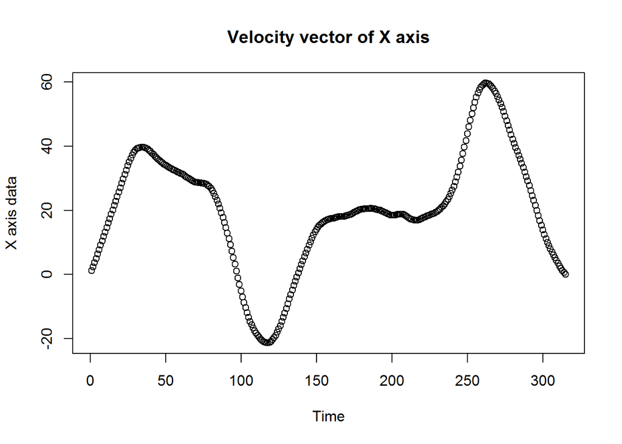

Figure 10: X axis for Class 2 with cumulative sum(Velocity vector of X axis)

This shows the graph of x axis belonging training data. In this case, cumulative sum is considered.

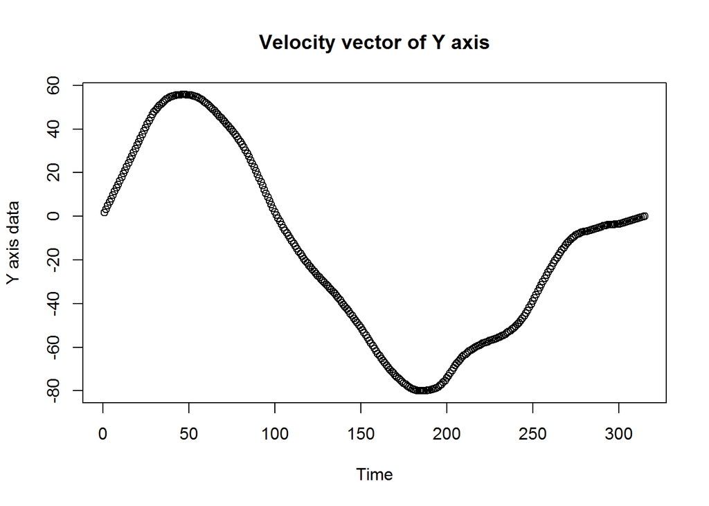

Figure 11: Y axis for Class 2 with cumulative sum(Velocity vector of Y axis)

This shows the graph of y axis belonging training data. In this case, cumulative sum is considered.

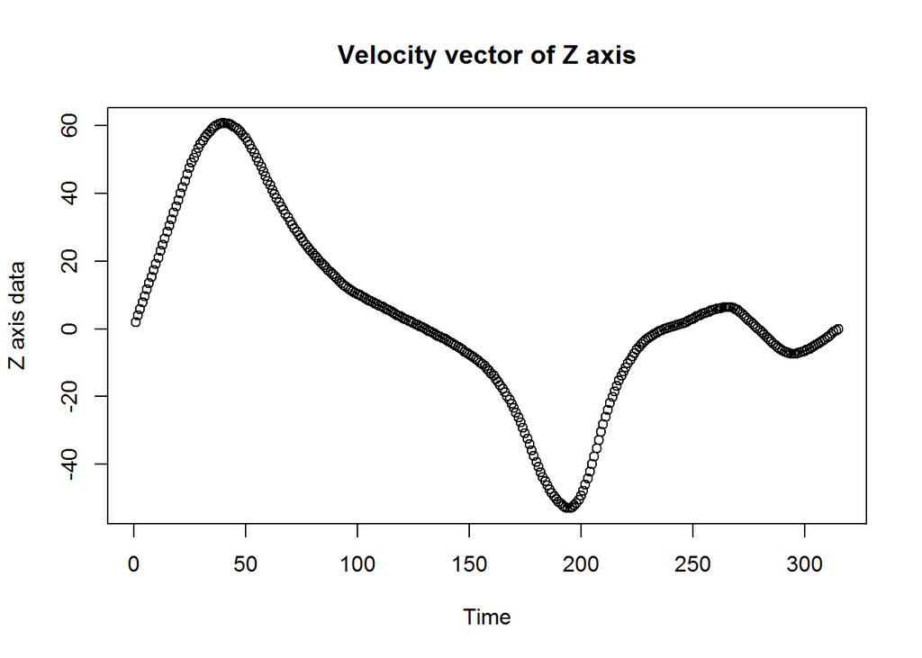

Figure 12: Z axis for Class 2 with cumulative sum(Velocity vector of Z axis)

This shows the graph of z axis belonging training data. In this case, cumulative sum is considered.

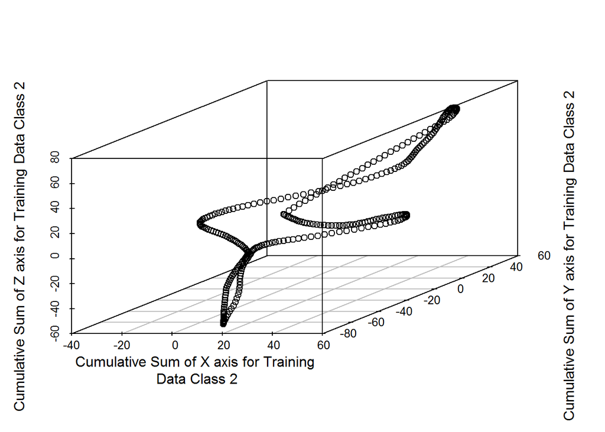

Figure 13: XYZ axis for Class 2 with cumulative sum(Velocity vector of XYZ axis)

This shows the graph of xyz axis belonging training data. In this case, cumulative sum is considered. This is the visualization of one instance of Class 2.

**For the 3. Class**

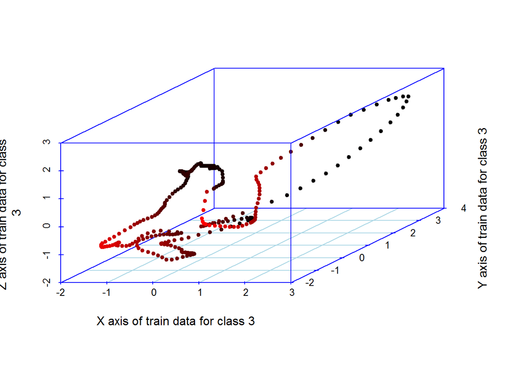

Figure 14: XYZ axis for class 3 without cumulative sum

If I want to see the combined version of x,y and z axis, this kind of plot can be observed.In this case, vectors are not cumulative.

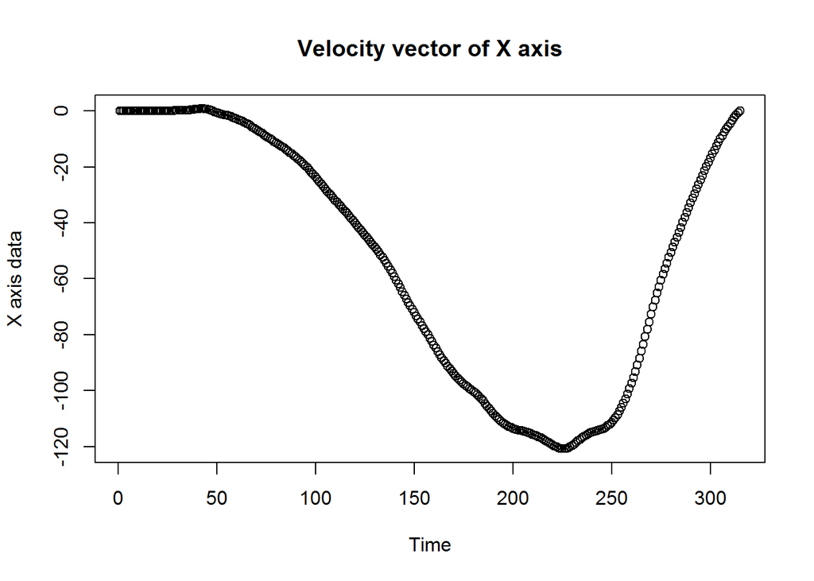

Figure 15: X axis for Class 3 with cumulative sum(Velocity vector of X axis)

This shows the graph of x axis belonging training data. In this case, cumulative sum is considered.

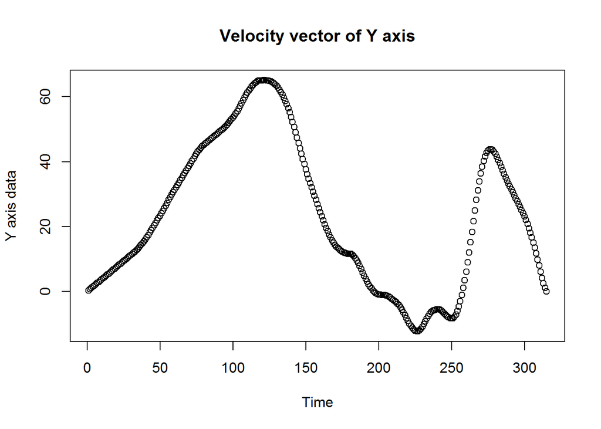

Figure 16: Y axis for Class 3 with cumulative sum(Velocity vector of Y axis)

This shows the graph of y axis belonging training data. In this case, cumulative sum is considered.

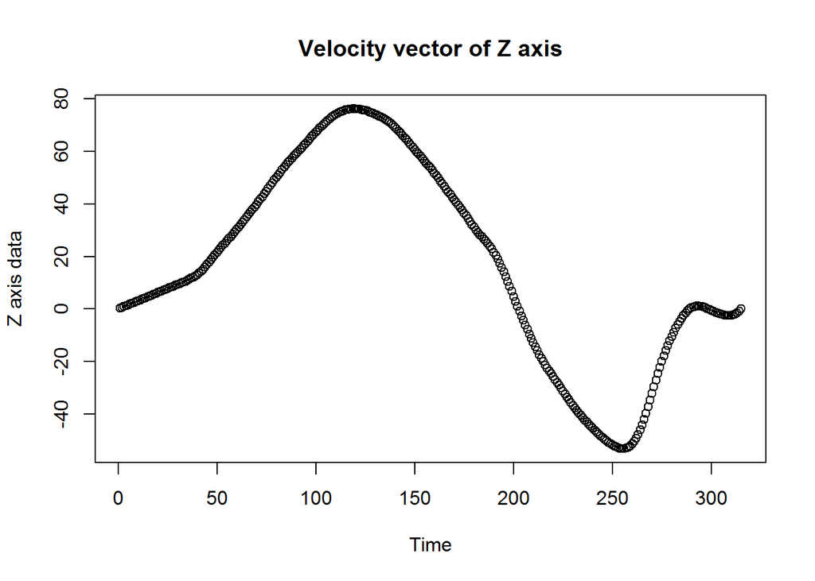

Figure 17: Z axis for Class 3 with cumulative sum(Velocity vector of Z axis)

This shows the graph of z axis belonging training data. In this case, cumulative sum is considered.

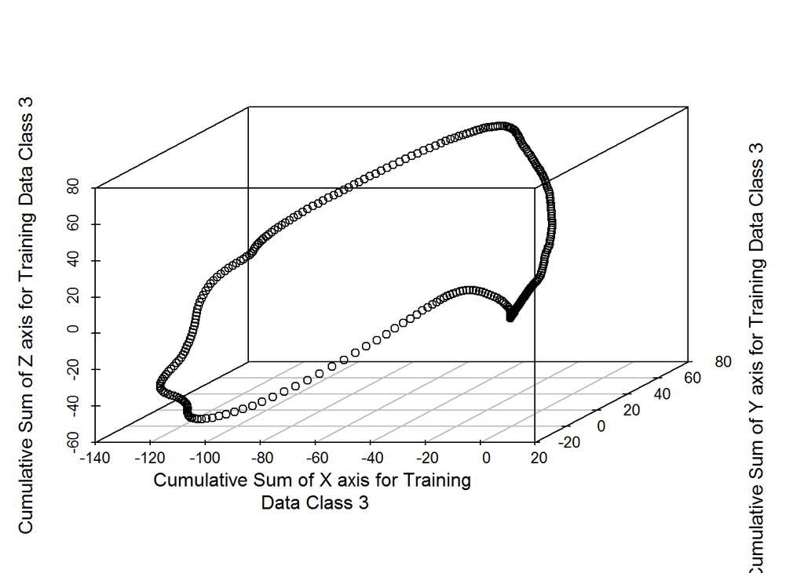

Figure 18: XYZ axis for Class 3 with cumulative sum(Velocity vector of XYZ axis)

This shows the graph of xyz axis belonging training data. In this case, cumulative sum is considered. This is the visualization of one instance of Class 3.

**For the 4. Class**

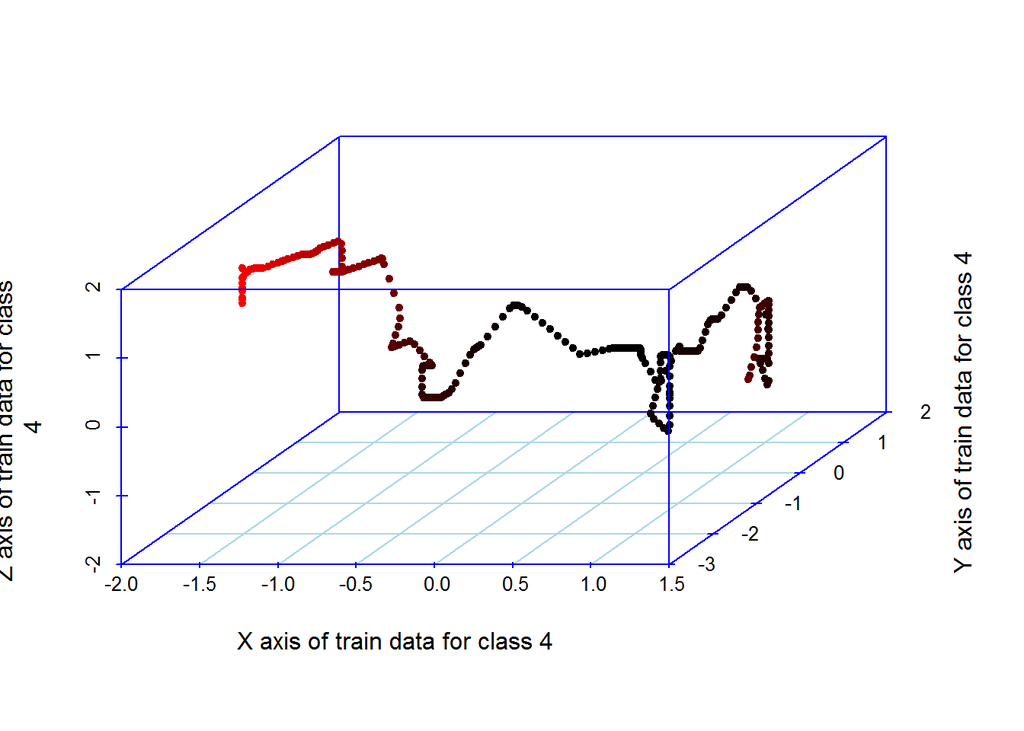

Figure 19: XYZ axis for class 4 without cumulative sum

If I want to see the combined version of x,y and z axis, this kind of plot can be observed.In this case, vectors are not cumulative.

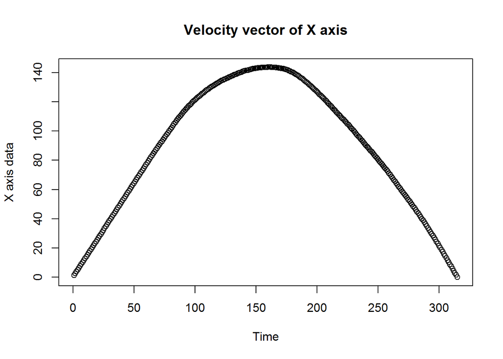

Figure 20: X axis for Class 4 with cumulative sum(Velocity vector of X axis)

This shows the graph of x axis belonging training data. In this case, cumulative sum is considered.

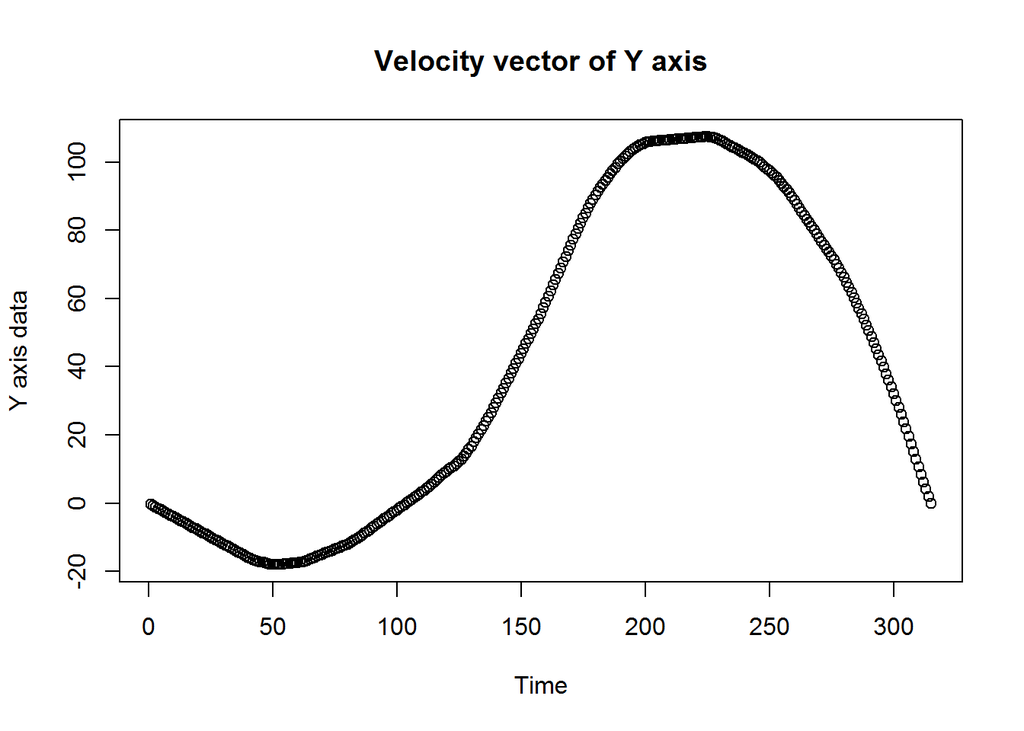

Figure 21: Y axis for Class 4 with cumulative sum(Velocity vector of Y axis)

This shows the graph of y axis belonging training data. In this case, cumulative sum is considered.

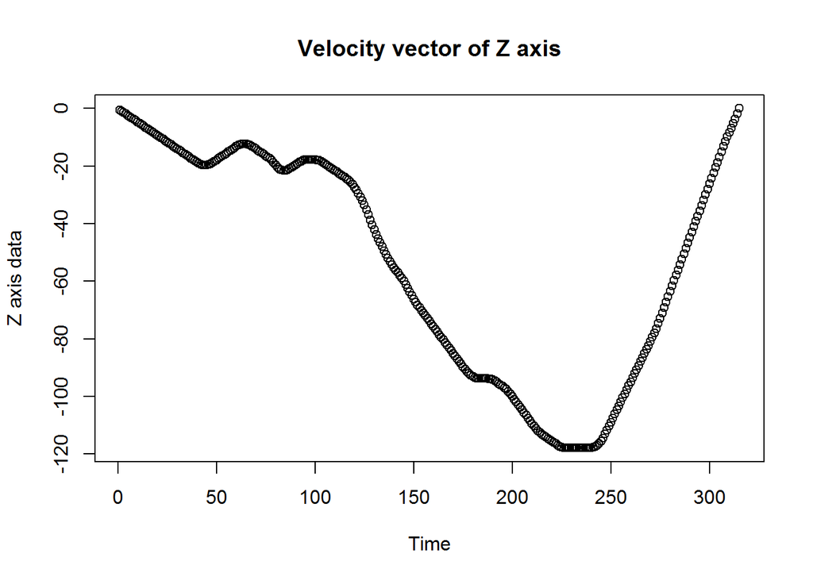

Figure 22: Z axis for Class 4 with cumulative sum(Velocity vector of Z axis)

This shows the graph of z axis belonging training data. In this case, cumulative sum is considered.

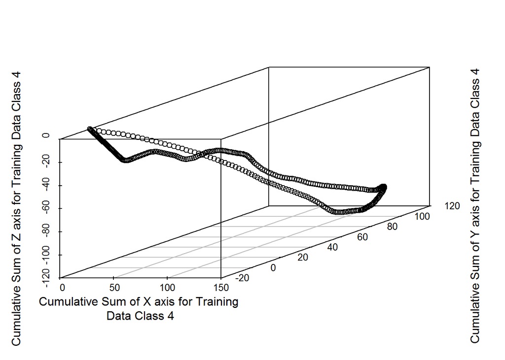

Figure 23: XYZ axis for Class 4 with cumulative sum(Velocity vector of XYZ axis)

This shows the graph of xyz axis belonging training data. In this case, cumulative sum is considered. This is the visualization of one instance of Class 4.

**For the 5. Class**

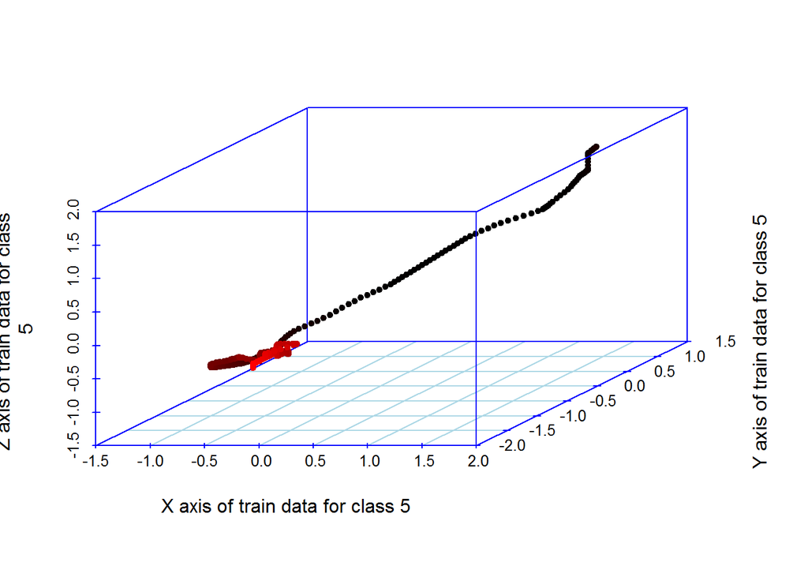

Figure 24: XYZ axis for class 5 without cumulative sum

If I want to see the combined version of x,y and z axis, this kind of plot can be observed.In this case, vectors are not cumulative.

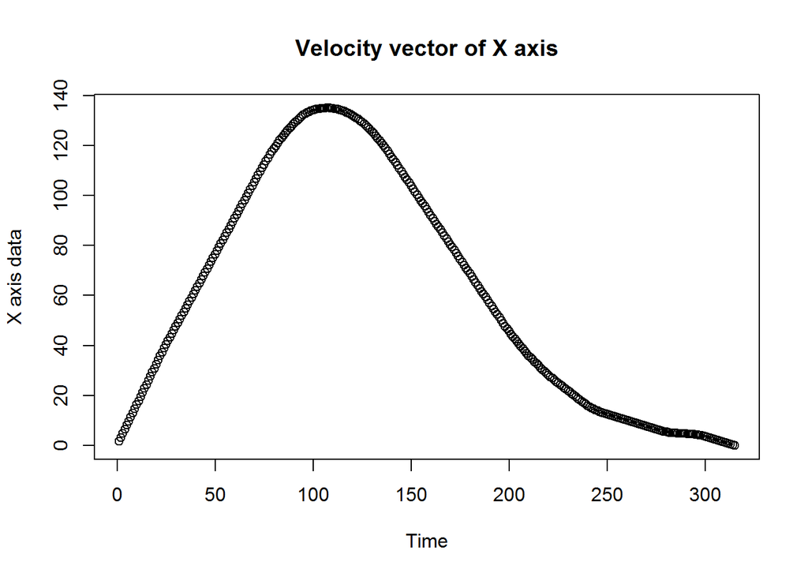

Figure 25: X axis for Class 5 with cumulative sum(Velocity vector of X axis)

This shows the graph of x axis belonging training data. In this case, cumulative sum is considered.

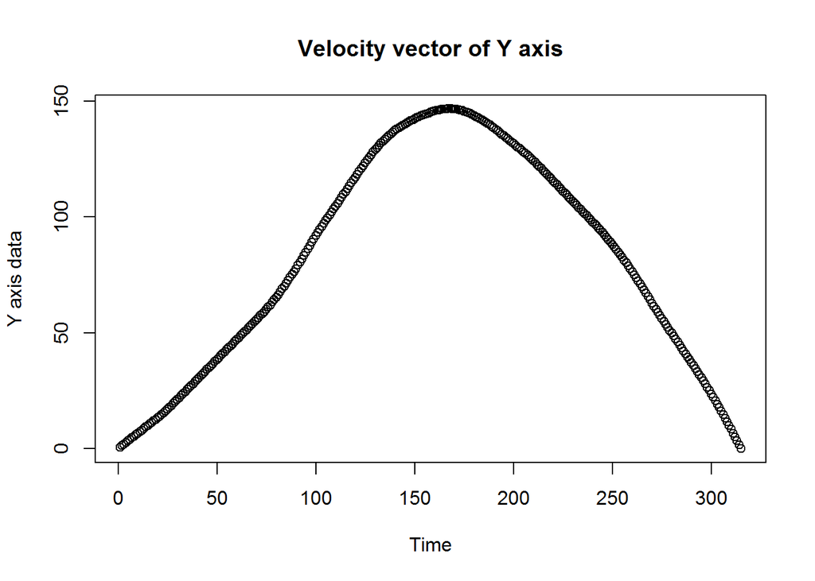

Figure 26: Y axis for Class 5 with cumulative sum(Velocity vector of Y axis)

This shows the graph of y axis belonging training data. In this case, cumulative sum is considered.

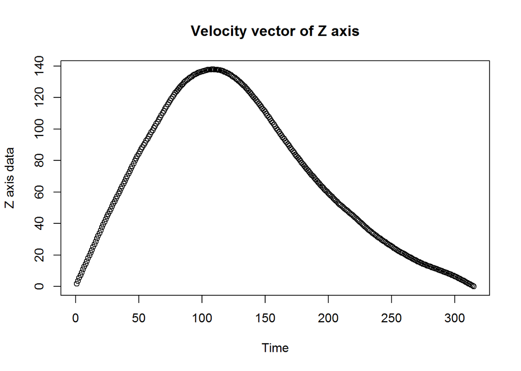

Figure 27: Z axis for Class 5 with cumulative sum(Velocity vector of Z axis)

This shows the graph of z axis belonging training data. In this case, cumulative sum is considered.

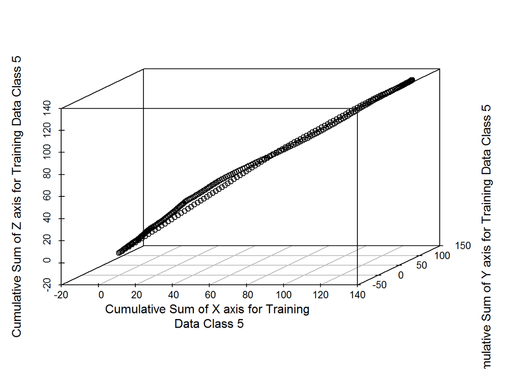

Figure 28: XYZ axis for Class 5 with cumulative sum(Velocity vector of XYZ axis)

This shows the graph of xyz axis belonging training data. In this case, cumulative sum is considered. This is the visualization of one instance of Class 5.

**For the 6. Class**

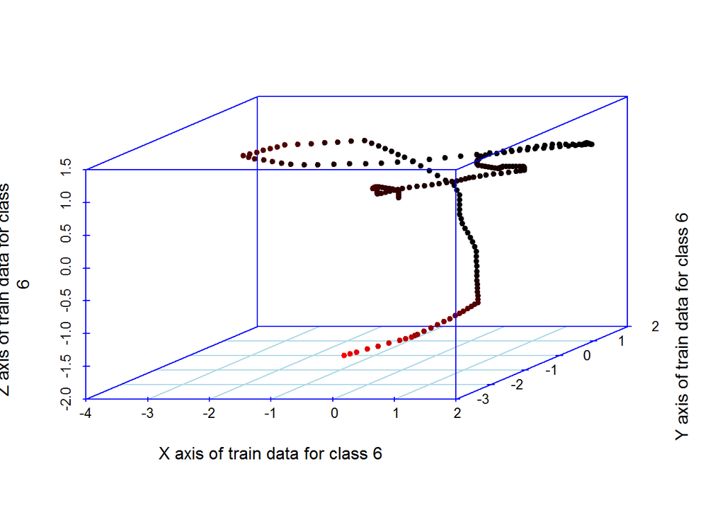

Figure 29: XYZ axis for class 6 without cumulative sum

If I want to see the combined version of x,y and z axis, this kind of plot can be observed.In this case, vectors are not cumulative.

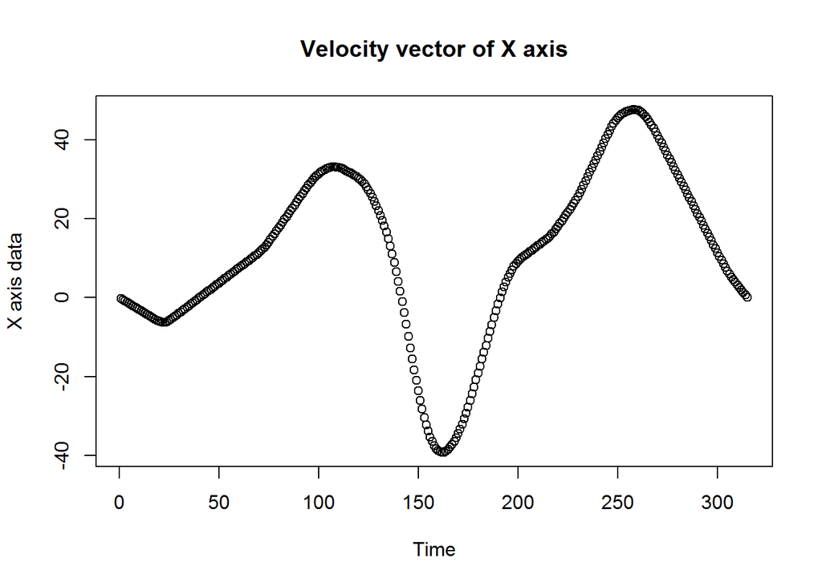

Figure 30: X axis for Class 6 with cumulative sum(Velocity vector of X axis)

This shows the graph of x axis belonging training data. In this case, cumulative sum is considered.

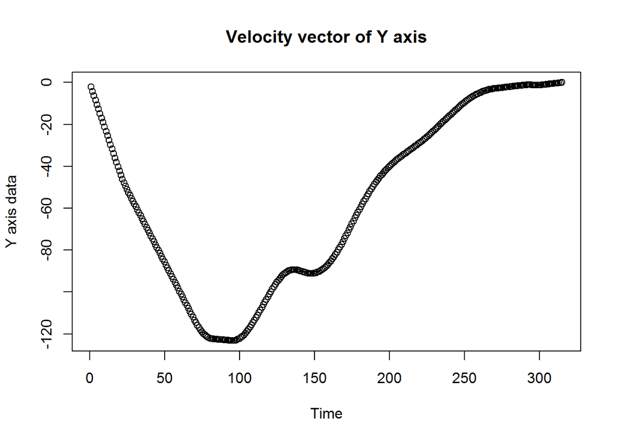

Figure 31: Y axis for Class 6 with cumulative sum(Velocity vector of Y axis)